# Statistiques SD Project

Alice Clément & Nino Pujals

2025-01-13

# Introduction

The objective of this report is to provide an analysis of the *Rossi* dataset which analyses the time before recidive of criminals in the USA depending on numerous covariates.

The main question is the following: **Does a financial help reduce the risk of recidive ?**

# Preparing dataset

## Load packages

```r
packages_names = c(
  'tidyverse',
  'survival',
  'ggsurvfit'
)

lapply(packages_names, library, character.only = TRUE)
```

## Load dataset

```r
Rossi <- read.csv("Rossi.csv", sep = ";", row.names=1)
```

## Inspect dataset

### General information

```r
head(Rossi)
```

```
##   week arrest fin age  race wexp         mar paro prio educ emp1 emp2 emp3 emp4
## 1   20      1  no  27 black   no not married  yes    3    3   no   no   no   no
## 2   17      1  no  18 black   no not married  yes    8    4   no   no   no   no
## 3   25      1  no  19 other  yes not married  yes   13    3   no   no   no   no
## 4   52      0 yes  23 black  yes     married  yes    1    5   no   no   no   no
## 5   52      0  no  19 other  yes not married  yes    3    3   no   no   no   no
## 6   52      0  no  24 black  yes not married   no    2    4   no   no   no   no
##   emp5 emp6 emp7 emp8 emp9 emp10 emp11 emp12 emp13 emp14 emp15 emp16 emp17
## 1   no   no   no   no   no    no    no    no    no    no    no    no    no
## 2   no   no   no   no   no   yes   yes   yes   yes   yes    no    no    no
## 3   no   no   no   no   no    no    no    no    no    no    no    no   yes
## 4  yes  yes  yes  yes  yes   yes   yes   yes   yes   yes   yes   yes   yes
## 5   no   no   no   no   no   yes   yes   yes   yes   yes   yes   yes   yes
## 6  yes  yes  yes  yes  yes   yes    no    no    no    no    no    no    no
##   emp18 emp19 emp20 emp21 emp22 emp23 emp24 emp25 emp26 emp27 emp28 emp29 emp30
```

[output cut: 20 more lines]

```r
dim_Rossi = dim(Rossi)
cat(paste("The dataset contains", dim_Rossi[1], "samples and", dim_Rossi[2], "features."))
```

```
## The dataset contains 432 samples and 62 features.
```

```r
col_names = colnames(Rossi)
cat(paste(c("The features are:", col_names, ".")))
```

```
## The features are: week arrest fin age race wexp mar paro prio educ emp1 emp2 emp3 emp4 emp5 emp6 emp7 emp8 emp9 emp10 emp11 emp12 emp13 emp14 emp15 emp16 emp17 emp18 emp19 emp20 emp21 emp22 emp23 emp24 emp25 emp26 emp27 emp28 emp29 emp30 emp31 emp32 emp33 emp34 emp35 emp36 emp37 emp38 emp39 emp40…
```

```r
unique_dt = unique((lapply(Rossi, class)))
cat(paste("The features of the dataset have the following datatypes:", paste(unique_dt) , "."))
```

```
## The features of the dataset have the following datatypes: integer . The features of the dataset have the following datatypes: character .
```

Here we can see that all the features of type `emp` correspond of being employed during the said week. The `NA` values correspond to weeks that occurred after the first arrest.

### New variable creation

Let us create a new variable to count the number of weeks of employment:

```r
# extracting useful columns
col_names = unlist(paste("emp", as.character(1:52), sep=""))
col_names_ind = which(colnames(Rossi) %in% col_names)

# converting "yes"/"no" to 1/0
convert_yes_no <- function(x){
  ifelse(x == "yes", 1, 0)
}
Rossi <- Rossi %>%
  mutate(across(all_of(col_names_ind), convert_yes_no))

# creating new feature
Rossi <- Rossi %>%
  mutate(nb_emp = rowSums(Rossi[col_names_ind], na.rm=TRUE))

# removing useless features
Rossi <- Rossi %>%
  select(-all_of(col_names_ind))

head(Rossi)
```

```
##   week arrest fin age  race wexp         mar paro prio educ nb_emp
## 1   20      1  no  27 black   no not married  yes    3    3      0
## 2   17      1  no  18 black   no not married  yes    8    4      5
## 3   25      1  no  19 other  yes not married  yes   13    3      1
## 4   52      0 yes  23 black  yes     married  yes    1    5     38
## 5   52      0  no  19 other  yes not married  yes    3    3     25
## 6   52      0  no  24 black  yes not married   no    2    4     13
```

## Missing values

```r
nb_mv = sum(is.na(Rossi))
pr_mv = nb_mv / prod(dim_Rossi) * 100
cat(paste("The number of missing values inside the dataset is:", nb_mv, "which makes for", pr_mv,"% of the dataset."))
```

```
## The number of missing values inside the dataset is: 0 which makes for 0 % of the dataset.
```

There is no missing values in the dataset, thus it is ready to be used.

# Survival model

## Financial aid

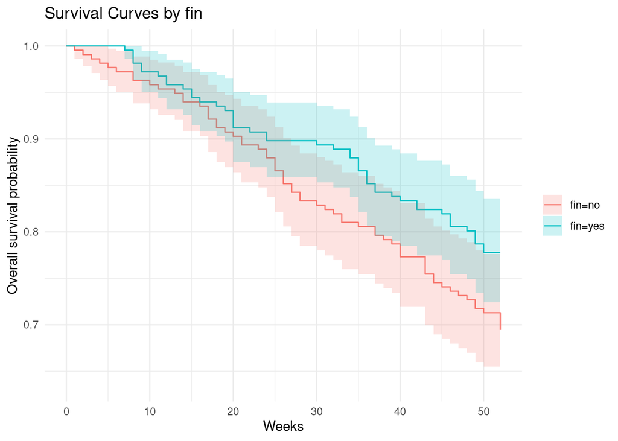

```r
# Adjust survival model with stratification
surv_model <- survfit(Surv(week, arrest) ~ fin, data = Rossi)

# plot with ggsurvfit
ggsurvfit(surv_model) +
  labs(
    x = "Weeks",
    y = "Overall survival probability",
    title = "Survival Curves by fin"
  ) +
  add_confidence_interval() +
  theme_minimal()
```

Here we can see that ex-prisoners that receive a financial aid upon their release have a higher survival function than those who do not.

## Race

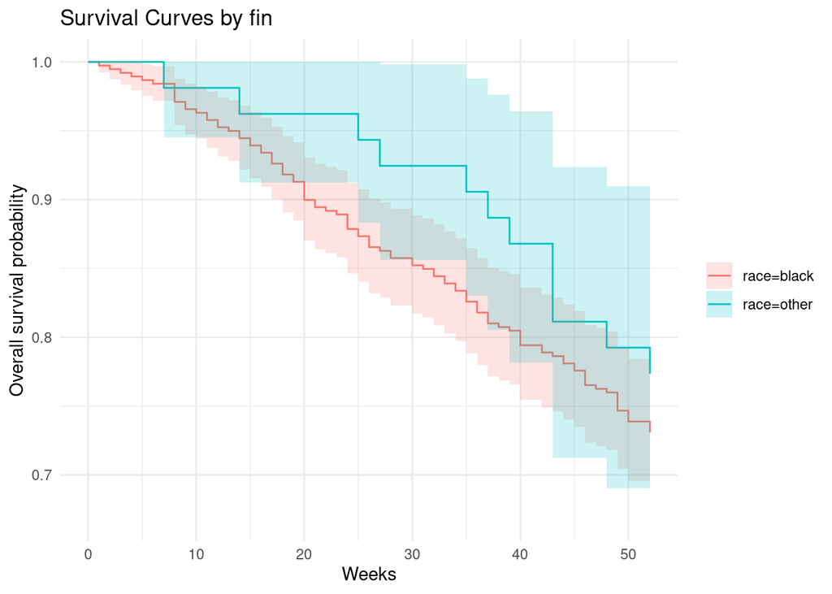

```r
# Ajuster le modèle de survie avec stratification
surv_model <- survfit(Surv(week, arrest) ~ race, data = Rossi)

# Tracer les courbes avec ggsurvfit
ggsurvfit(surv_model) +
  labs(
    x = "Weeks",
    y = "Overall survival probability",
    title = "Survival Curves by fin"
  ) +
  add_confidence_interval() +
  theme_minimal()
```

Here we can see that ex-prisoners that are of black ethnicity have a lower survival function than those who are not.

## Accelerated Feature Time Model

```r
aft_model <- survreg(formula = Surv(week, arrest) ~ fin + age + race + wexp + mar + paro + prio + educ + nb_emp, data = Rossi)
summary(aft_model)
```

```
##
## Call:
## survreg(formula = Surv(week, arrest) ~ fin + age + race + wexp +
##     mar + paro + prio + educ + nb_emp, data = Rossi)
##                   Value Std. Error     z       p
## (Intercept)     3.19152    0.56632  5.64 1.7e-08
## finyes          0.19548    0.13163  1.49   0.138
## age             0.02576    0.01461  1.76   0.078
## raceother       0.26190    0.21529  1.22   0.224
## wexpyes        -0.09141    0.14519 -0.63   0.529
## marnot married -0.03672    0.26317 -0.14   0.889
## paroyes         0.01503    0.13323  0.11   0.910
## prio           -0.04317    0.02075 -2.08   0.037
## educ            0.13373    0.09087  1.47   0.141
## nb_emp          0.03682    0.00613  6.01 1.9e-09
## Log(scale)     -0.38166    0.08705 -4.38 1.2e-05
##
## Scale= 0.683
##
## Weibull distribution
## Loglik(model)= -647.9   Loglik(intercept only)= -696.6
##  Chisq= 97.41 on 9 degrees of freedom, p= 5.2e-17
## Number of Newton-Raphson Iterations: 8
## n= 432
```

We consider only the features with significantly low p-value.

Each week of employment during the year after the release increases the time before arrest by 3%.

Each prior arrest decreases the time before arrest by 4%.